# Sofala Simple Spatial Survey Method (S3M)

Survey Progress

Mark Myatt

Ernest Guevarra

2022-04-27 17:22:09

# 1. Records by sampling point

## 1.1. Number of records per sampling point as of 2022-04-27 17:22:09

Number of records per SP ID

| SP ID | Number of records |
| --- | --- |
| 0 | 3 |
| 1 | 1 |
| 100 | 20 |
| 102 | 19 |
| 103 | 20 |
| 104 | 10 |
| 105 | 18 |
| 112 | 20 |
| 114 | 19 |
| 117 | 16 |
| 127 | 20 |
| 139 | 20 |
| 142 | 5 |
| 151 | 20 |
| 163 | 20 |
| 171 | 1 |
| 19 | 20 |
| 20 | 15 |
| 210 | 21 |
| 211 | 10 |
| 212 | 21 |
| 213 | 20 |
| 214 | 20 |
| 215 | 8 |
| 216 | 20 |
| 217 | 10 |
| 229 | 11 |
| 26 | 15 |
| 27 | 19 |
| 28 | 20 |
| 29 | 18 |
| 30 | 21 |
| 34 | 5 |
| 35 | 20 |
| 36 | 20 |
| 38 | 3 |
| 39 | 2 |
| 44 | 15 |
| 45 | 20 |
| 5 | 1 |
| 52 | 20 |
| 53 | 16 |
| 56 | 14 |
| 59 | 22 |
| 60 | 19 |
| 61 | 20 |
| 62 | 18 |
| 63 | 5 |
| 66 | 19 |
| 68 | 20 |
| 70 | 20 |
| 71 | 14 |
| 72 | 19 |
| 73 | 19 |
| 74 | 12 |
| 75 | 19 |
| 76 | 17 |
| 77 | 21 |
| 79 | 11 |
| 80 | 15 |
| 81 | 20 |
| 82 | 20 |
| 83 | 20 |
| 84 | 21 |
| 85 | 20 |
| 86 | 16 |
| 90 | 20 |
| 91 | 20 |
| 93 | 20 |
| 94 | 15 |
| 95 | 8 |
| Total | 1127 |
| Total records with incorrect SP ID | 3 |

Sampling point identifiers in **BOLD RED are unrecognised/illegal values** for this variable.

Sampling point identifiers in **BOLD BLUE are sampling points with less than 20 records**.

## 1.2. Number of records by sampling point and by date

Number of records by SP ID per day

| SP ID | 2022-04-13 | 2022-04-14 | 2022-04-15 | 2022-04-16 | 2022-04-17 | 2022-04-18 | 2022-04-19 | 2022-04-20 | 2022-04-21 | 2022-04-22 | 2022-04-23 | 2022-04-24 | 2022-04-25 | 2022-04-26 | 2022-04-27 | Total records by SP ID per day |
| --- | --- | --- | --- | --- | --- | --- | --- | --- | --- | --- | --- | --- | --- | --- | --- | --- |
| 0 | 0 | 0 | 0 | 0 | 0 | 0 | 0 | 3 | 0 | 0 | 0 | 0 | 0 | 0 | 0 | 3 |
| 1 | 0 | 0 | 0 | 0 | 0 | 0 | 0 | 0 | 0 | 0 | 0 | 0 | 0 | 1 | 0 | 1 |
| 100 | 0 | 0 | 0 | 0 | 0 | 20 | 0 | 0 | 0 | 0 | 0 | 0 | 0 | 0 | 0 | 20 |
| 102 | 0 | 0 | 0 | 0 | 0 | 0 | 0 | 0 | 0 | 0 | 0 | 0 | 0 | 19 | 0 | 19 |
| 103 | 0 | 0 | 0 | 0 | 0 | 0 | 0 | 0 | 0 | 0 | 20 | 0 | 0 | 0 | 0 | 20 |
| 104 | 0 | 0 | 0 | 10 | 0 | 0 | 0 | 0 | 0 | 0 | 0 | 0 | 0 | 0 | 0 | 10 |
| 105 | 0 | 0 | 0 | 0 | 0 | 0 | 18 | 0 | 0 | 0 | 0 | 0 | 0 | 0 | 0 | 18 |
| 112 | 0 | 0 | 0 | 0 | 0 | 0 | 20 | 0 | 0 | 0 | 0 | 0 | 0 | 0 | 0 | 20 |
| 114 | 1 | 0 | 0 | 18 | 0 | 0 | 0 | 0 | 0 | 0 | 0 | 0 | 0 | 0 | 0 | 19 |
| 117 | 0 | 0 | 0 | 0 | 0 | 0 | 0 | 0 | 0 | 0 | 16 | 0 | 0 | 0 | 0 | 16 |
| 127 | 0 | 0 | 0 | 0 | 0 | 0 | 0 | 16 | 0 | 0 | 0 | 4 | 0 | 0 | 0 | 20 |
| 139 | 0 | 0 | 0 | 0 | 0 | 0 | 0 | 1 | 19 | 0 | 0 | 0 | 0 | 0 | 0 | 20 |
| 142 | 0 | 0 | 0 | 0 | 0 | 0 | 0 | 0 | 0 | 0 | 0 | 0 | 0 | 0 | 5 | 5 |
| 151 | 0 | 0 | 0 | 0 | 0 | 0 | 0 | 0 | 1 | 19 | 0 | 0 | 0 | 0 | 0 | 20 |
| 163 | 0 | 0 | 0 | 0 | 0 | 0 | 0 | 0 | 0 | 0 | 20 | 0 | 0 | 0 | 0 | 20 |
| 171 | 0 | 0 | 0 | 0 | 0 | 0 | 0 | 0 | 0 | 0 | 1 | 0 | 0 | 0 | 0 | 1 |
| 19 | 0 | 0 | 0 | 0 | 0 | 0 | 0 | 0 | 0 | 20 | 0 | 0 | 0 | 0 | 0 | 20 |
| 20 | 0 | 0 | 0 | 0 | 0 | 0 | 0 | 0 | 0 | 0 | 0 | 0 | 15 | 0 | 0 | 15 |
| 210 | 2 | 0 | 0 | 0 | 0 | 0 | 0 | 0 | 19 | 0 | 0 | 0 | 0 | 0 | 0 | 21 |
| 211 | 0 | 0 | 0 | 0 | 0 | 0 | 0 | 0 | 0 | 0 | 0 | 0 | 0 | 10 | 0 | 10 |
| 212 | 0 | 0 | 0 | 0 | 0 | 0 | 20 | 0 | 0 | 0 | 1 | 0 | 0 | 0 | 0 | 21 |
| 213 | 0 | 0 | 0 | 0 | 0 | 0 | 0 | 0 | 0 | 20 | 0 | 0 | 0 | 0 | 0 | 20 |
| 214 | 0 | 0 | 0 | 0 | 0 | 0 | 0 | 0 | 0 | 0 | 15 | 0 | 5 | 0 | 0 | 20 |
| 215 | 0 | 0 | 0 | 0 | 0 | 0 | 0 | 0 | 0 | 0 | 0 | 0 | 0 | 8 | 0 | 8 |
| 216 | 0 | 0 | 0 | 0 | 0 | 0 | 0 | 0 | 0 | 0 | 0 | 0 | 6 | 14 | 0 | 20 |
| 217 | 0 | 0 | 0 | 0 | 0 | 0 | 0 | 0 | 10 | 0 | 0 | 0 | 0 | 0 | 0 | 10 |
| 229 | 0 | 0 | 1 | 0 | 0 | 0 | 0 | 0 | 0 | 0 | 0 | 0 | 0 | 1 | 9 | 11 |
| 26 | 0 | 0 | 0 | 15 | 0 | 0 | 0 | 0 | 0 | 0 | 0 | 0 | 0 | 0 | 0 | 15 |
| 27 | 0 | 0 | 0 | 0 | 0 | 0 | 0 | 0 | 19 | 0 | 0 | 0 | 0 | 0 | 0 | 19 |
| 28 | 0 | 0 | 0 | 0 | 0 | 0 | 0 | 0 | 0 | 0 | 20 | 0 | 0 | 0 | 0 | 20 |
| 29 | 0 | 0 | 0 | 0 | 0 | 0 | 18 | 0 | 0 | 0 | 0 | 0 | 0 | 0 | 0 | 18 |
| 30 | 0 | 0 | 0 | 0 | 0 | 0 | 0 | 21 | 0 | 0 | 0 | 0 | 0 | 0 | 0 | 21 |
| 34 | 0 | 0 | 0 | 5 | 0 | 0 | 0 | 0 | 0 | 0 | 0 | 0 | 0 | 0 | 0 | 5 |
| 35 | 0 | 0 | 15 | 5 | 0 | 0 | 0 | 0 | 0 | 0 | 0 | 0 | 0 | 0 | 0 | 20 |
| 36 | 0 | 0 | 1 | 0 | 0 | 19 | 0 | 0 | 0 | 0 | 0 | 0 | 0 | 0 | 0 | 20 |
| 38 | 0 | 0 | 0 | 0 | 0 | 0 | 0 | 0 | 0 | 0 | 0 | 0 | 3 | 0 | 0 | 3 |
| 39 | 0 | 0 | 0 | 0 | 0 | 0 | 2 | 0 | 0 | 0 | 0 | 0 | 0 | 0 | 0 | 2 |
| 44 | 0 | 0 | 0 | 0 | 0 | 0 | 0 | 0 | 0 | 0 | 15 | 0 | 0 | 0 | 0 | 15 |
| 45 | 0 | 0 | 0 | 0 | 0 | 0 | 0 | 6 | 14 | 0 | 0 | 0 | 0 | 0 | 0 | 20 |
| 5 | 0 | 0 | 0 | 0 | 0 | 0 | 0 | 0 | 0 | 0 | 0 | 0 | 0 | 1 | 0 | 1 |
| 52 | 0 | 0 | 0 | 0 | 0 | 0 | 0 | 20 | 0 | 0 | 0 | 0 | 0 | 0 | 0 | 20 |
| 53 | 0 | 0 | 0 | 0 | 0 | 0 | 0 | 0 | 0 | 16 | 0 | 0 | 0 | 0 | 0 | 16 |
| 56 | 0 | 0 | 0 | 0 | 0 | 0 | 0 | 0 | 0 | 0 | 0 | 0 | 1 | 13 | 0 | 14 |
| 59 | 0 | 0 | 1 | 21 | 0 | 0 | 0 | 0 | 0 | 0 | 0 | 0 | 0 | 0 | 0 | 22 |
| 60 | 1 | 4 | 14 | 0 | 0 | 0 | 0 | 0 | 0 | 0 | 0 | 0 | 0 | 0 | 0 | 19 |
| 61 | 0 | 0 | 0 | 0 | 0 | 0 | 0 | 20 | 0 | 0 | 0 | 0 | 0 | 0 | 0 | 20 |
| 62 | 2 | 0 | 11 | 5 | 0 | 0 | 0 | 0 | 0 | 0 | 0 | 0 | 0 | 0 | 0 | 18 |
| 63 | 0 | 0 | 0 | 0 | 0 | 0 | 0 | 0 | 0 | 0 | 0 | 0 | 0 | 0 | 5 | 5 |
| 66 | 0 | 0 | 0 | 0 | 0 | 19 | 0 | 0 | 0 | 0 | 0 | 0 | 0 | 0 | 0 | 19 |
| 68 | 0 | 20 | 0 | 0 | 0 | 0 | 0 | 0 | 0 | 0 | 0 | 0 | 0 | 0 | 0 | 20 |
| 70 | 0 | 0 | 0 | 0 | 0 | 19 | 1 | 0 | 0 | 0 | 0 | 0 | 0 | 0 | 0 | 20 |
| 71 | 0 | 0 | 0 | 0 | 0 | 0 | 0 | 0 | 0 | 14 | 0 | 0 | 0 | 0 | 0 | 14 |
| 72 | 0 | 0 | 0 | 0 | 0 | 0 | 0 | 0 | 0 | 0 | 0 | 0 | 13 | 6 | 0 | 19 |
| 73 | 0 | 0 | 0 | 0 | 0 | 0 | 0 | 0 | 0 | 0 | 0 | 0 | 7 | 12 | 0 | 19 |
| 74 | 0 | 2 | 0 | 10 | 0 | 0 | 0 | 0 | 0 | 0 | 0 | 0 | 0 | 0 | 0 | 12 |
| 75 | 0 | 0 | 0 | 8 | 11 | 0 | 0 | 0 | 0 | 0 | 0 | 0 | 0 | 0 | 0 | 19 |
| 76 | 0 | 0 | 0 | 0 | 0 | 0 | 1 | 16 | 0 | 0 | 0 | 0 | 0 | 0 | 0 | 17 |
| 77 | 0 | 0 | 0 | 0 | 0 | 0 | 0 | 0 | 0 | 1 | 20 | 0 | 0 | 0 | 0 | 21 |
| 79 | 0 | 0 | 0 | 0 | 0 | 0 | 0 | 0 | 11 | 0 | 0 | 0 | 0 | 0 | 0 | 11 |
| 80 | 0 | 0 | 0 | 0 | 0 | 0 | 0 | 0 | 0 | 0 | 0 | 0 | 15 | 0 | 0 | 15 |
| 81 | 0 | 0 | 0 | 0 | 0 | 0 | 0 | 20 | 0 | 0 | 0 | 0 | 0 | 0 | 0 | 20 |
| 82 | 0 | 0 | 0 | 0 | 0 | 0 | 0 | 0 | 20 | 0 | 0 | 0 | 0 | 0 | 0 | 20 |
| 83 | 0 | 0 | 0 | 0 | 0 | 9 | 11 | 0 | 0 | 0 | 0 | 0 | 0 | 0 | 0 | 20 |
| 84 | 0 | 0 | 3 | 10 | 0 | 8 | 0 | 0 | 0 | 0 | 0 | 0 | 0 | 0 | 0 | 21 |
| 85 | 0 | 0 | 0 | 0 | 0 | 15 | 5 | 0 | 0 | 0 | 0 | 0 | 0 | 0 | 0 | 20 |
| 86 | 0 | 0 | 0 | 0 | 0 | 0 | 0 | 10 | 0 | 6 | 0 | 0 | 0 | 0 | 0 | 16 |
| 90 | 0 | 0 | 0 | 0 | 0 | 0 | 0 | 0 | 0 | 8 | 12 | 0 | 0 | 0 | 0 | 20 |
| 91 | 0 | 0 | 0 | 0 | 0 | 10 | 10 | 0 | 0 | 0 | 0 | 0 | 0 | 0 | 0 | 20 |
| 93 | 0 | 0 | 20 | 0 | 0 | 0 | 0 | 0 | 0 | 0 | 0 | 0 | 0 | 0 | 0 | 20 |
| 94 | 0 | 0 | 0 | 0 | 0 | 0 | 0 | 0 | 0 | 0 | 0 | 0 | 15 | 0 | 0 | 15 |
| 95 | 0 | 0 | 0 | 0 | 0 | 0 | 0 | 8 | 0 | 0 | 0 | 0 | 0 | 0 | 0 | 8 |
| Total | 6 | 26 | 66 | 107 | 11 | 119 | 106 | 141 | 113 | 104 | 140 | 4 | 80 | 85 | 19 | 1127 |
| Total records with incorrect SP ID per day | 0 | 0 | 0 | 0 | 0 | 0 | 0 | 3 | 0 | 0 | 0 | 0 | 0 | 0 | 0 | 3 |

Sampling point identiferis in **BOLD RED are unrecognised/illegal values** for this variable.

Sampling point identifiers in **BOLD BLUE are sampling points with less than 20 records**.

## 1.3. Survey teams recording incorrect sampling point identifiers

| Survey Team | Number of records with incorrect SP ID |
| --- | --- |
| 1 | 3 |

## 1.4. Map of records collected by enumeration area

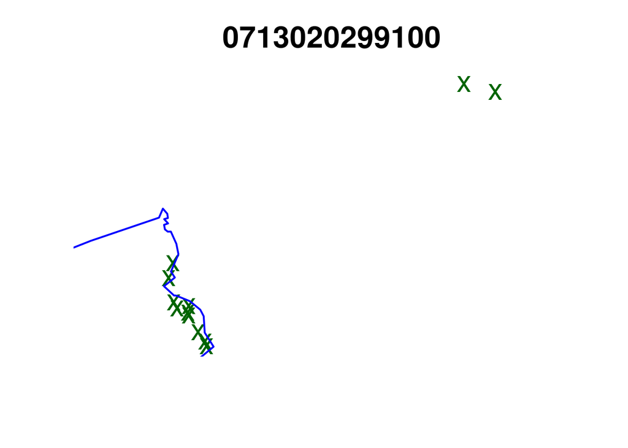

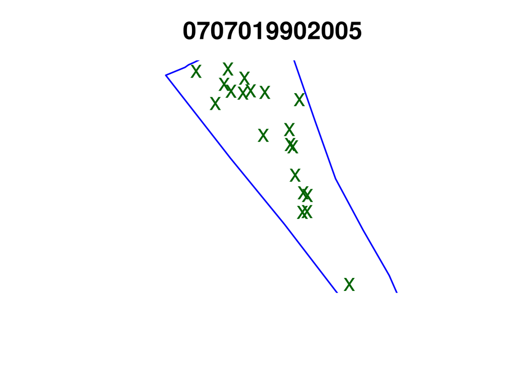

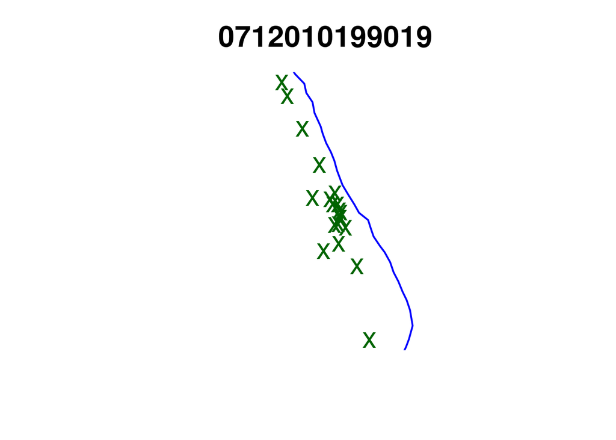

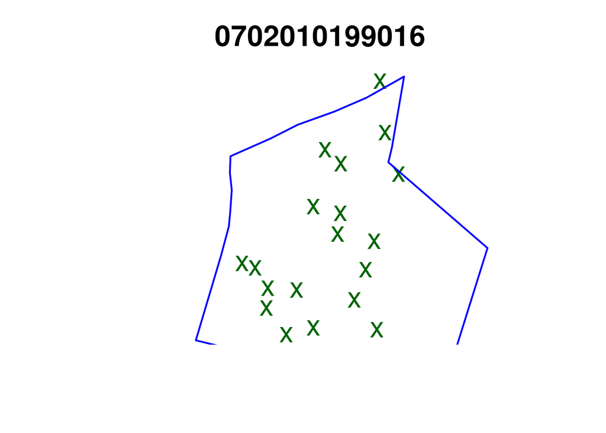

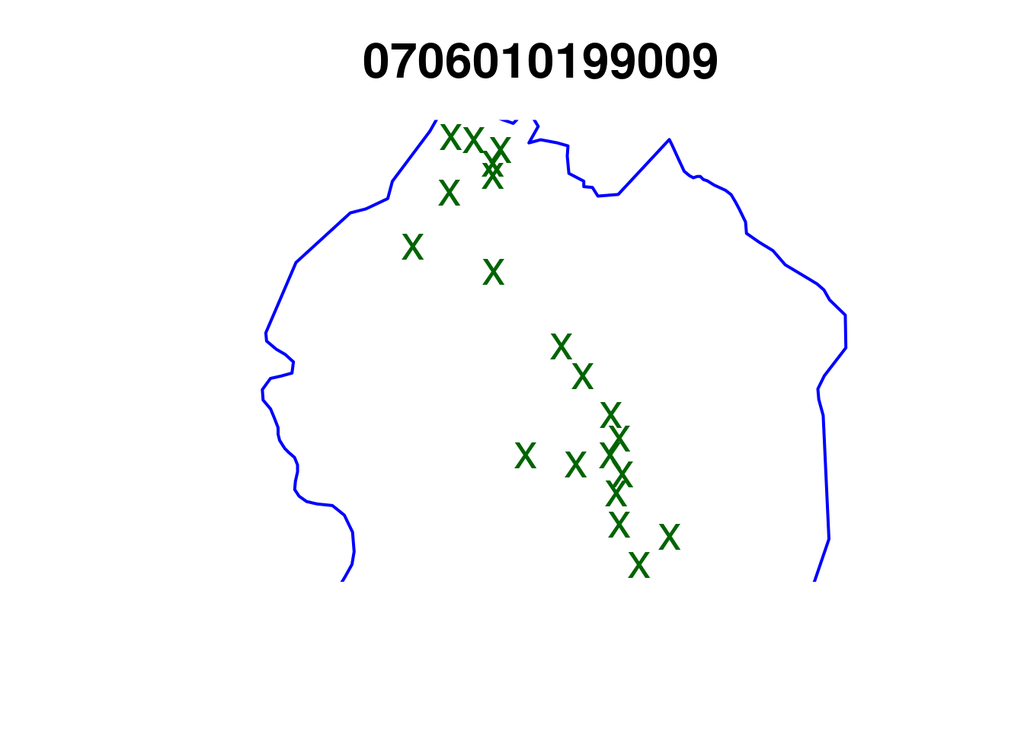

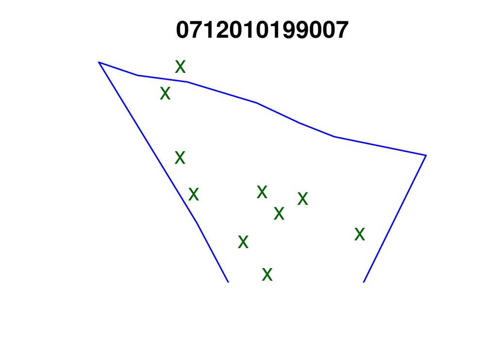

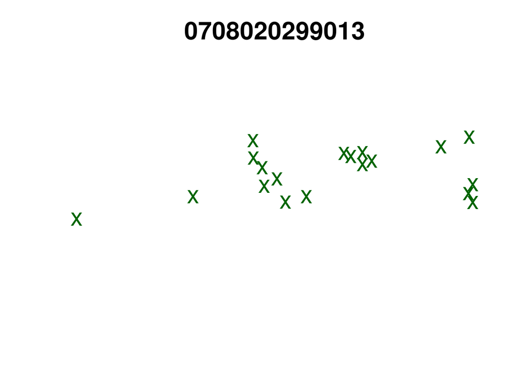

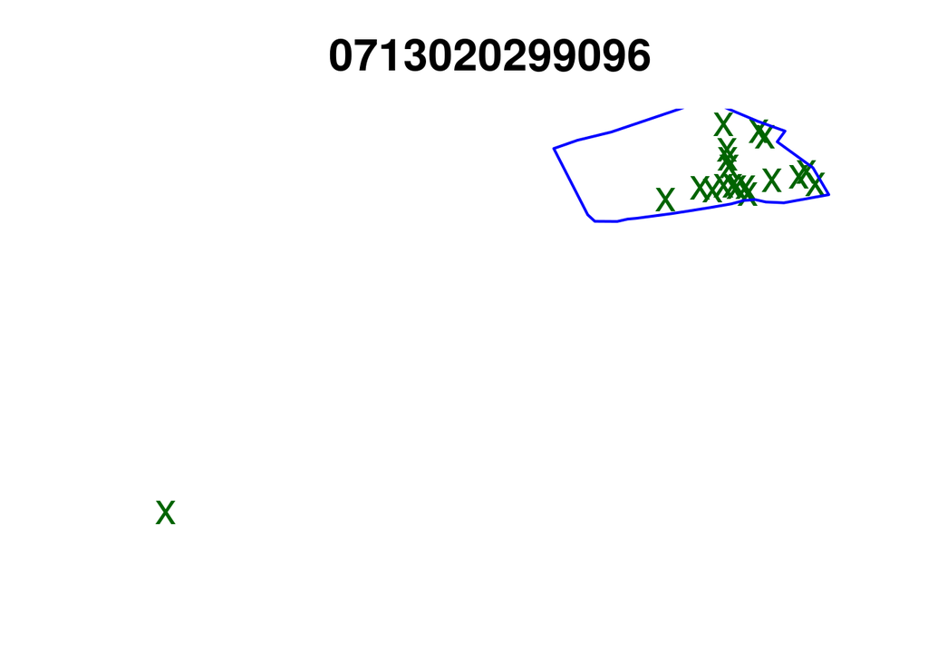

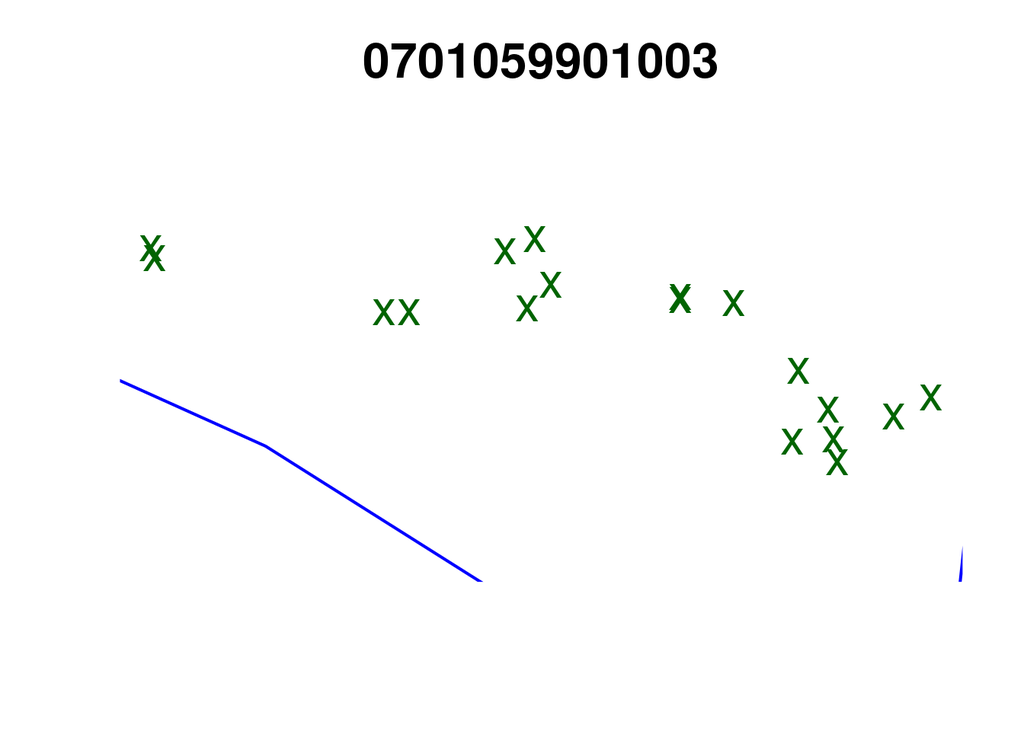

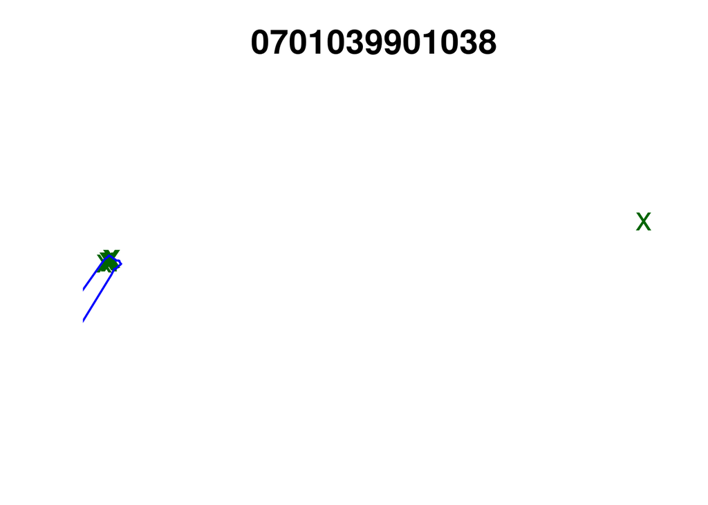

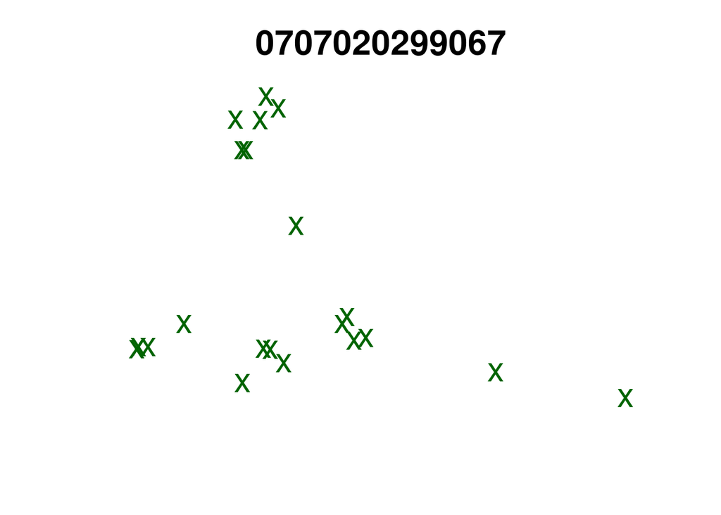

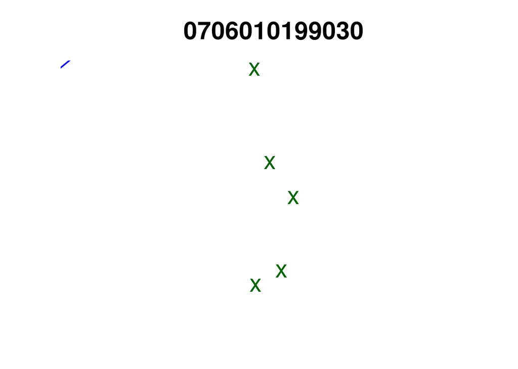

[54 more figures not shown]

Map of records collected by enumeration area

We expect that the **location of records (points in green)** are within the **boundaries of the enumeration area** in which they were reported to have been collected. If record locations are outside of these boundaries, there may be issues with the GPS recorded or the enumeration area selected.

Number of records collected within appropriate enumeration area

| Enumeration Area | Records collected within EA | Records collected oustide EA | Total Records |
| --- | --- | --- | --- |
| 0713020299100 | 10 | 2 | 12 |
| 0707019902005 | 20 | 0 | 20 |
| 0712010199019 | 20 | 0 | 20 |
| 0702010199016 | 18 | 1 | 19 |
| 0706010199009 | 20 | 0 | 20 |
| 0712010199007 | 9 | 1 | 10 |
| 0708020299013 | 19 | 0 | 19 |
| 0713020299096 | 18 | 1 | 19 |
| 0701059901003 | 18 | 0 | 18 |
| 0701039901038 | 10 | 1 | 11 |
| 0707020299067 | 0 | 21 | 21 |
| 0706010199030 | 5 | 0 | 5 |
| 0702010499024 | 21 | 1 | 22 |
| 0706010199028 | 0 | 15 | 15 |
| 0702010499001 | 18 | 1 | 19 |
| 0713010699084 | 20 | 0 | 20 |
| 0713010899008 | 19 | 1 | 20 |
| 0708020299014 | 20 | 0 | 20 |
| 0712020699004 | 15 | 0 | 15 |
| 0701059903002 | 17 | 3 | 20 |
| 0706030199016 | 16 | 4 | 20 |
| NA | 0 | 0 | 0 |
| 0706030199065 | 5 | 0 | 5 |
| 0707019901024 | 1 | 1 | 2 |
| 0702020199010 | 19 | 1 | 20 |
| 0701029901002 | 16 | 4 | 20 |
| 0712020199007 | 16 | 0 | 16 |
| 0712010199018 | 7 | 0 | 7 |
| 0712020199004 | 5 | 0 | 5 |
| 0706030299049 | 16 | 0 | 16 |
| 0713010799045 | 20 | 0 | 20 |
| 0708020199033 | 18 | 2 | 20 |
| 0708020199020 | 20 | 0 | 20 |
| 0702020199051 | 18 | 2 | 20 |
| 0712020399010 | 11 | 0 | 11 |
| 0701059903004 | 10 | 0 | 10 |
| 0706030399037 | 18 | 0 | 18 |
| 0713010799073 | 20 | 0 | 20 |
| 0701039906032 | 19 | 1 | 20 |
| 0713010599011 | 20 | 0 | 20 |
| 0708020199005 | 20 | 0 | 20 |
| 0707019907016 | 5 | 0 | 5 |
| 0702020199022 | 16 | 0 | 16 |
| 0706030499039 | 16 | 0 | 16 |
| 0708020199002 | 19 | 1 | 20 |
| 0712010199001 | 0 | 15 | 15 |
| 0711020199011 | 0 | 1 | 1 |
| 0712010199006 | 0 | 11 | 11 |
| 0701059903008 | 20 | 0 | 20 |
| 0706030499007 | 17 | 0 | 17 |
| 0707030299006 | 6 | 0 | 6 |
| 0702020199035 | 14 | 1 | 15 |
| 0707030199030 | 6 | 0 | 6 |
| 0706030499016 | 13 | 0 | 13 |
| 0702020499048 | 0 | 3 | 3 |
| 0701059903006 | 20 | 0 | 20 |
| 0712020499002 | 0 | 15 | 15 |
| 0712020399006 | 0 | 15 | 15 |
| 0708010299052 | 19 | 0 | 19 |
| 0709010299001 | 0 | 1 | 1 |
| 0706020599016 | 14 | 0 | 14 |
| 0701059903009 | 8 | 0 | 8 |
| 0707030299015 | 2 | 3 | 5 |
| 0713010799116 | 0 | 19 | 19 |
| 0713010799114 | 0 | 19 | 19 |
| 0709010299003 | 0 | 1 | 1 |
| 0708030299001 | 5 | 0 | 5 |
| Total | 792 | 168 | 960 |

Enumeration areas in **BOLD RED are areas having records collected outside of the enumeration area**.

A total of **168** records were collected outside of the appropriate enumeration area.

Following are the records that have been collected outside of the appropriate enumeration areas.

| Record Identifier | Survey Team | Enumerator Code | Survey Date | Enumeration Area |
| --- | --- | --- | --- | --- |
| 95759339 | 3 | 301 | 2022-04-16 | 0713020299100 |
| 95759345 | 3 | 301 | 2022-04-16 | 0713020299100 |
| 95732094 | 11 | 1103 | 2022-04-15 | 0702010199016 |
| 95750977 | 10 | 1005 | 2022-04-16 | 0712010199007 |
| 95760378 | 4 | 405 | 2022-04-16 | 0713020299096 |
| 95760907 | 14 | 1405 | 2022-04-15 | 0701039901038 |
| 95766429 | 2 | 206 | 2022-04-15 | 0707020299067 |
| 95766430 | 2 | 206 | 2022-04-15 | 0707020299067 |
| 95808579 | 2 | 206 | 2022-04-15 | 0707020299067 |
| 95762071 | 1 | 103 | 2022-04-16 | 0707020299067 |
| 95777711 | 1 | 103 | 2022-04-16 | 0707020299067 |
| 95777741 | 1 | 103 | 2022-04-16 | 0707020299067 |
| 95808394 | 2 | 205 | 2022-04-16 | 0707020299067 |
| 95808395 | 2 | 205 | 2022-04-16 | 0707020299067 |
| 95808583 | 2 | 206 | 2022-04-16 | 0707020299067 |
| 95809071 | 1 | 101 | 2022-04-16 | 0707020299067 |
| 95809073 | 1 | 101 | 2022-04-16 | 0707020299067 |
| 95809075 | 1 | 101 | 2022-04-16 | 0707020299067 |
| 95813941 | 1 | 101 | 2022-04-16 | 0707020299067 |
| 95802958 | 1 | 103 | 2022-04-18 | 0707020299067 |
| 95802960 | 1 | 103 | 2022-04-18 | 0707020299067 |
| 95808396 | 2 | 205 | 2022-04-18 | 0707020299067 |
| 95808397 | 2 | 205 | 2022-04-18 | 0707020299067 |
| 95808399 | 2 | 205 | 2022-04-18 | 0707020299067 |
| 95808587 | 2 | 206 | 2022-04-18 | 0707020299067 |
| 95809076 | 1 | 101 | 2022-04-18 | 0707020299067 |
| 95809077 | 1 | 101 | 2022-04-18 | 0707020299067 |
| 95847543 | 12 | 1205 | 2022-04-15 | 0702010499024 |
| 95777193 | 8 | 806 | 2022-04-16 | 0706010199028 |
| 95777194 | 8 | 806 | 2022-04-16 | 0706010199028 |

[output cut: 138 more lines]

# 2. Records by survey team

## 2.1. Number of records per survey team as of 2022-04-27 17:22:18

Number of records per survey team

| Survey Team | Number of records |
| --- | --- |
| 1 | 71 |
| 2 | 77 |
| 3 | 89 |
| 4 | 81 |
| 5 | 85 |
| 6 | 79 |
| 7 | 95 |
| 8 | 99 |
| 9 | 84 |
| 10 | 86 |
| 11 | 64 |
| 12 | 70 |
| 13 | 34 |
| 14 | 113 |
| Total | 1127 |

## 2.2. Number of records per survey team per day as of 2022-04-27 17:22:18

Number of records per survey team per day

| Survey Team | 2022-04-13 | 2022-04-14 | 2022-04-15 | 2022-04-16 | 2022-04-17 | 2022-04-18 | 2022-04-19 | 2022-04-20 | 2022-04-21 | 2022-04-22 | 2022-04-23 | 2022-04-24 | 2022-04-25 | 2022-04-26 | 2022-04-27 | Total records by Survey Team per day |
| --- | --- | --- | --- | --- | --- | --- | --- | --- | --- | --- | --- | --- | --- | --- | --- | --- |
| 1 | 0 | 10 | 0 | 7 | 0 | 4 | 10 | 10 | 11 | 4 | 10 | 0 | 0 | 5 | 0 | 71 |
| 2 | 2 | 10 | 3 | 3 | 0 | 4 | 11 | 9 | 8 | 11 | 11 | 0 | 0 | 5 | 0 | 77 |
| 3 | 0 | 2 | 0 | 10 | 6 | 9 | 11 | 11 | 11 | 4 | 6 | 0 | 7 | 12 | 0 | 89 |
| 4 | 0 | 0 | 0 | 8 | 5 | 10 | 10 | 9 | 9 | 4 | 6 | 0 | 13 | 7 | 0 | 81 |
| 5 | 0 | 0 | 0 | 10 | 0 | 10 | 10 | 6 | 11 | 9 | 10 | 4 | 0 | 10 | 5 | 85 |
| 6 | 1 | 0 | 0 | 8 | 0 | 10 | 10 | 11 | 9 | 10 | 10 | 0 | 0 | 10 | 0 | 79 |
| 7 | 0 | 0 | 7 | 13 | 0 | 10 | 10 | 10 | 10 | 10 | 10 | 0 | 6 | 4 | 5 | 95 |
| 8 | 0 | 0 | 9 | 12 | 0 | 9 | 10 | 11 | 9 | 10 | 10 | 0 | 10 | 9 | 0 | 99 |
| 9 | 0 | 0 | 10 | 5 | 0 | 15 | 5 | 8 | 6 | 0 | 20 | 0 | 15 | 0 | 0 | 84 |
| 10 | 0 | 0 | 10 | 5 | 0 | 0 | 18 | 10 | 5 | 6 | 17 | 0 | 15 | 0 | 0 | 86 |
| 11 | 1 | 2 | 7 | 11 | 0 | 9 | 0 | 13 | 7 | 6 | 5 | 0 | 3 | 0 | 0 | 64 |
| 12 | 0 | 2 | 8 | 10 | 0 | 10 | 0 | 13 | 7 | 10 | 10 | 0 | 0 | 0 | 0 | 70 |
| 13 | 0 | 0 | 3 | 2 | 0 | 5 | 0 | 5 | 2 | 5 | 4 | 0 | 3 | 5 | 0 | 34 |
| 14 | 2 | 0 | 9 | 3 | 0 | 14 | 1 | 15 | 8 | 15 | 11 | 0 | 8 | 18 | 9 | 113 |
| Total | 6 | 26 | 66 | 107 | 11 | 119 | 106 | 141 | 113 | 104 | 140 | 4 | 80 | 85 | 19 | 1127 |